# Shawn’s study notes on Bayesian Statistics

The Bayesian Statistics course is from Coursera by Duke University.

## 1. Basics of Bayesian Probability:

> The example of RU-486 (contraceptive):  
> 40 women came to health clinic asking for emergency contraception,  
> randomly assign 20 to RU-486 & 20 to standard therapy,  
> 4 out of 20 in RU-486(treatment) became pregnant,  
> 16 out of 20 in standard therapy(control) were pregnant.  
> Question:  
> How strongly do these data indicate that the treatment is more effective than the control?

```r
df <- data.frame(
  Group = c("Treated","Control"),
  Pregnant = c(4,16),
  Not_Pregnant = c(16,4)
)

library(kableExtra)
kable(df) %>%
  kable_styling(font_size = 20, full_width = FALSE)
```

| Group | Pregnant | Not_Pregnant |
| --- | --- | --- |
| Treated | 4 | 16 |
| Control | 16 | 4 |

### *Simplification – one proportion: 20 total pregnancies, how likely is it that 4 pregnancies occur in the treatment group? (vs 10 from treatment)*

## **1.1 Frequentist Method:**

### H<sub>0</sub>: p=0.5, H<sub>A</sub>: p<0.5

### Then with binomial distribution probability,

$$P(X = k) = \binom{n}{k} \, p^k \, (1-p)^{n-k}$$

### the p-value=P(k<=4) is the sum of the probability of k=0,1,2,3,4 while n=20:

```r
sum(dbinom(0:4, size=20, p=0.5))
```

```
## [1] 0.005908966
```

### which means the chances of observing 4 or less pregnancies in the treatment group, given that pregnancy was equally likely in the two groups is approximately 0.0059, which will reject the H<sub>0</sub>.

## **1.2 Bayesian Method:**

*(same assumption that 50%(p) out of 20 pregnancies came from treatment group means treatment = control, versus <50% from treatment)*

### 1st, assume p, the chances that the preganancies came from treatment group, could be 10%, 20%, 30%, 40%, 50%, 60%, 70%, 80%, or 90%.

### 2nd, specify the prior, which is the relevant research up to current time, but not incorporate info from current experiment.

[output not shown]

### The benefit of treatment is set to symmetic, so it’s equally likely to be better or worse than the standard treatment.

### 3rd, calculate the Likelihood, P(data|model), for each model. E.g.: P(data|model)=P(k=4|n=20,p)

```r
p <- round(seq(from = 0.1, to = 0.9, by = 0.1), digits=1)
prior <- round(c(rep(0.06,4),0.52, rep(0.06,4)), digits=2)
likelihood <- round(dbinom(4, size=20, prob = p), digits=4)

library(dplyr)
df1 <- as.data.frame(rbind(p,prior,likelihood))
names(df1) <- NULL

rownames(df1) <- c("Model (p)","Prior, P(model)","Likelihood, P(data|model)")

library(kableExtra)

kable(df1, format="html", escape=FALSE) %>%
  kable_styling(font_size = 20, full_width = TRUE)
```

| Model (p) | 0.1000 | 0.2000 | 0.3000 | 0.400 | 0.5000 | 6e-01 | 0.70 | 0.80 | 0.90 |
| --- | --- | --- | --- | --- | --- | --- | --- | --- | --- |
| Prior, P(model) | 0.0600 | 0.0600 | 0.0600 | 0.060 | 0.5200 | 6e-02 | 0.06 | 0.06 | 0.06 |
| Likelihood, P(data\|model) | 0.0898 | 0.2182 | 0.1304 | 0.035 | 0.0046 | 3e-04 | 0.00 | 0.00 | 0.00 |

### 4th, Calculate Posterior: i.e. P(model|data)

$$P(model | data) = \frac{P(model \& data)}{P(data)} =
\frac{P(data|model)*P(model)}{P(data)}$$

```r
numerator   <- round(prior * likelihood,digits=4)
denominator <- round(sum(numerator),digits=4)
denominator
```

```
## [1] 0.0308
```

```r
posterior   <- round(numerator / denominator,digits=4)

df1b <- as.data.frame(rbind(p,prior,likelihood,numerator,posterior))
names(df1b) <- NULL

rownames(df1b) <- c("Model (p)","Prior, P(model)","Likelihood, P(data|model)","Numerator, P(data|model)*P(model)","Posterior, P(model|data)")

library(kableExtra)

kable(df1b, format="html", escape=FALSE) %>%
  kable_styling(font_size = 20, full_width = TRUE) %>%
  column_spec(column = 3, background = "yellow", bold=TRUE)
```

| Model (p) | 0.1000 | 0.2000 | 0.3000 | 0.4000 | 0.5000 | 6e-01 | 0.70 | 0.80 | 0.90 |
| --- | --- | --- | --- | --- | --- | --- | --- | --- | --- |
| Prior, P(model) | 0.0600 | 0.0600 | 0.0600 | 0.0600 | 0.5200 | 6e-02 | 0.06 | 0.06 | 0.06 |
| Likelihood, P(data\|model) | 0.0898 | 0.2182 | 0.1304 | 0.0350 | 0.0046 | 3e-04 | 0.00 | 0.00 | 0.00 |
| Numerator, P(data\|model)*P(model) | 0.0054 | 0.0131 | 0.0078 | 0.0021 | 0.0024 | 0e+00 | 0.00 | 0.00 | 0.00 |
| Posterior, P(model\|data) | 0.1753 | 0.4253 | 0.2532 | 0.0682 | 0.0779 | 0e+00 | 0.00 | 0.00 | 0.00 |

```r
sum(posterior)
```

```
## [1] 0.9999
```

### So the highlighted column is the most likely model, based on the observed data, even we give lower prior p (0.06), it’s posterior p is the highest.

### And in Bayesian paradigm, it allows we make direct probability statements about the models, like sum the posteriors of the models where p<0.5, which is about 0.9216 chance that the treatment is more effective than controls.

## **2. Effect of Sample Size on the Posterior**

```r
barplot(prior, main="Prior")
```

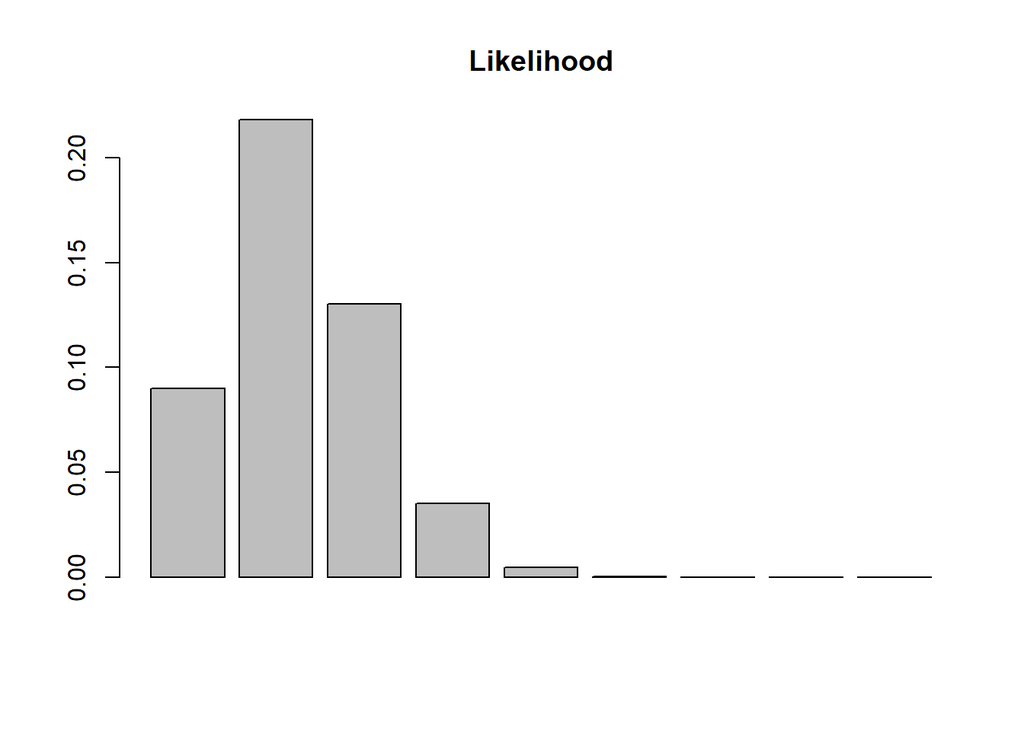

```r
barplot(likelihood, main="Likelihood")
```

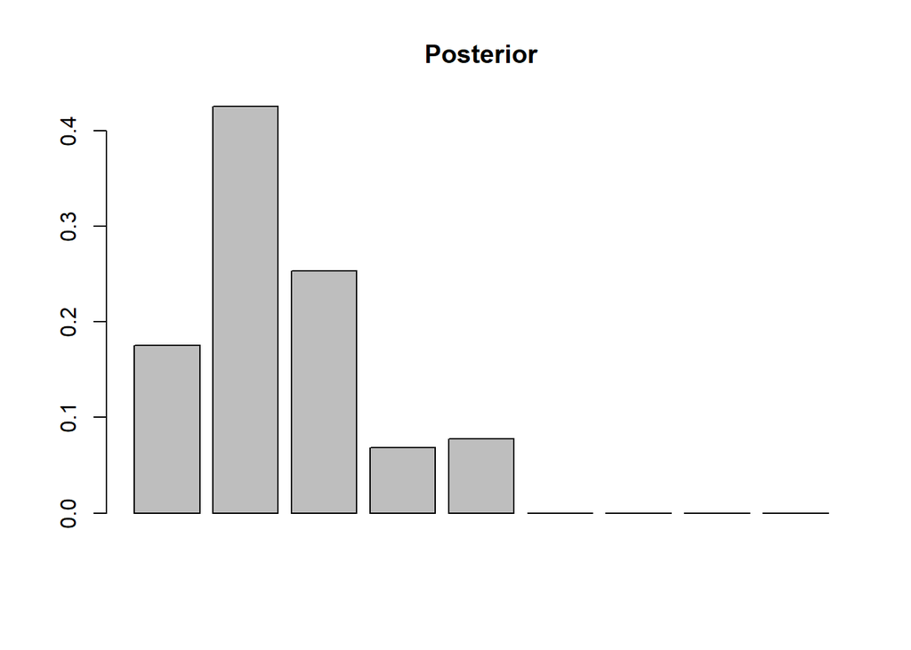

```r
barplot(posterior, main="Posterior")
```

### Then what if n=40, k=8?

```r
p2 <- round(seq(from = 0.1, to = 0.9, by = 0.1), digits=1)
prior2 <- round(c(rep(0.06,4),0.52, rep(0.06,4)), digits=2)

likelihood2 <- round(dbinom(8, size=40, prob = p), digits=4)

numerator2   <- round(prior2 * likelihood2,digits=4)
denominator2 <- round(sum(numerator2),digits=4)
denominator2
```

```
## [1] 0.0146
```

```r
posterior2   <- round(numerator2 / denominator2,digits=4)

library(dplyr)
df2 <- as.data.frame(rbind(p2,prior2,likelihood2,numerator2,posterior2))
names(df2) <- NULL

rownames(df2) <- c("Model (p)","Prior, P(model)","Likelihood, P(data|model)","Numerator, P(data|model)*P(model)","Posterior, P(model|data)")

library(kableExtra)

kable(df2, format="html", escape=FALSE) %>%
  kable_styling(font_size = 20, full_width = TRUE) %>%
  column_spec(column = 3, background = "yellow", bold=TRUE)
```

| Model (p) | 0.1000 | 0.2000 | 0.3000 | 0.4000 | 0.5000 | 0.60 | 0.70 | 0.80 | 0.90 |
| --- | --- | --- | --- | --- | --- | --- | --- | --- | --- |
| Prior, P(model) | 0.0600 | 0.0600 | 0.0600 | 0.0600 | 0.5200 | 0.06 | 0.06 | 0.06 | 0.06 |
| Likelihood, P(data\|model) | 0.0264 | 0.1560 | 0.0557 | 0.0040 | 0.0001 | 0.00 | 0.00 | 0.00 | 0.00 |
| Numerator, P(data\|model)*P(model) | 0.0016 | 0.0094 | 0.0033 | 0.0002 | 0.0001 | 0.00 | 0.00 | 0.00 | 0.00 |
| Posterior, P(model\|data) | 0.1096 | 0.6438 | 0.2260 | 0.0137 | 0.0068 | 0.00 | 0.00 | 0.00 | 0.00 |

```r
sum(posterior)
```

```
## [1] 0.9999
```

```r
barplot(prior2, main="Prior")
```

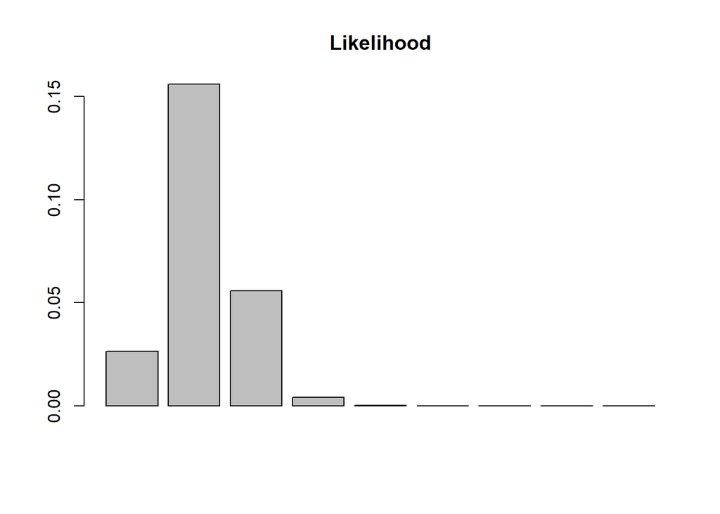

```r
barplot(likelihood2, main="Likelihood")
```

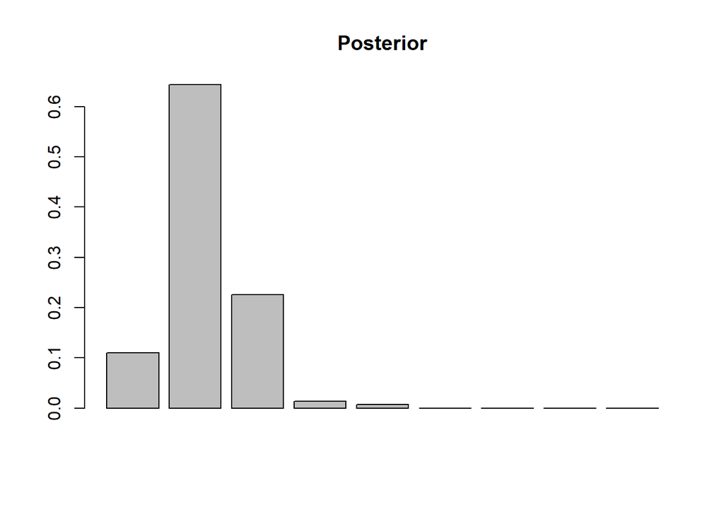

```r
barplot(posterior2, main="Posterior")
```

### And what if n=200, k=40?

```r
p3 <- round(seq(from = 0.1, to = 0.9, by = 0.1), digits=1)
prior3 <- round(c(rep(0.06,4),0.52, rep(0.06,4)), digits=2)

likelihood3 <- round(dbinom(40, size=200, prob = p), digits=4)

numerator3   <- round(prior3 * likelihood3,digits=4)
denominator3 <- round(sum(numerator3),digits=4)
denominator3
```

```
## [1] 0.0042
```

```r
posterior3   <- round(numerator3 / denominator3,digits=4)

library(dplyr)
df3 <- as.data.frame(rbind(p3,prior3,likelihood3,numerator3,posterior3))
names(df3) <- NULL

rownames(df3) <- c("Model (p)","Prior, P(model)","Likelihood, P(data|model)","Numerator, P(data|model)*P(model)","Posterior, P(model|data)")

library(kableExtra)

kable(df3, format="html", escape=FALSE) %>%
  kable_styling(font_size = 20, full_width = TRUE) %>%
  column_spec(column = 3, background = "yellow", bold=TRUE)
```

| Model (p) | 0.10 | 0.2000 | 3e-01 | 0.40 | 0.50 | 0.60 | 0.70 | 0.80 | 0.90 |
| --- | --- | --- | --- | --- | --- | --- | --- | --- | --- |
| Prior, P(model) | 0.06 | 0.0600 | 6e-02 | 0.06 | 0.52 | 0.06 | 0.06 | 0.06 | 0.06 |
| Likelihood, P(data\|model) | 0.00 | 0.0704 | 4e-04 | 0.00 | 0.00 | 0.00 | 0.00 | 0.00 | 0.00 |
| Numerator, P(data\|model)*P(model) | 0.00 | 0.0042 | 0e+00 | 0.00 | 0.00 | 0.00 | 0.00 | 0.00 | 0.00 |
| Posterior, P(model\|data) | 0.00 | 1.0000 | 0e+00 | 0.00 | 0.00 | 0.00 | 0.00 | 0.00 | 0.00 |

```r
sum(posterior)
```

```
## [1] 0.9999
```

```r
barplot(prior3, main="Prior")
```

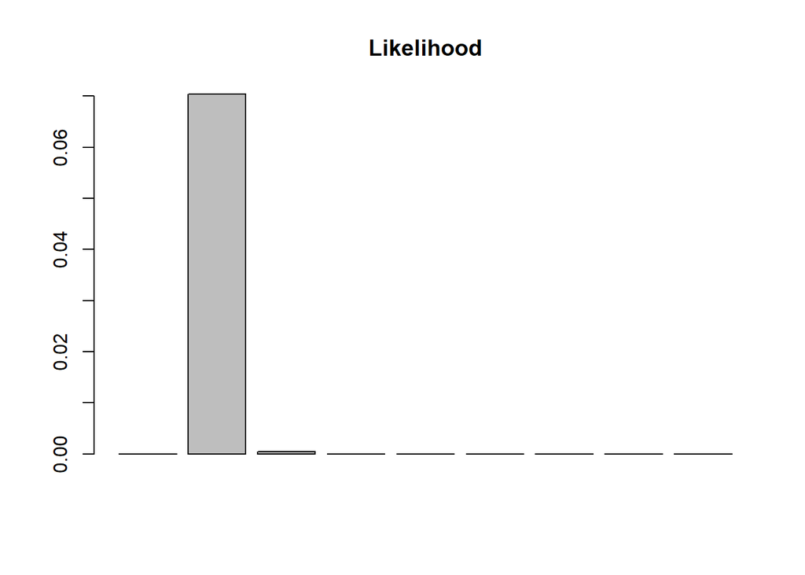

```r
barplot(likelihood3, main="Likelihood")
```

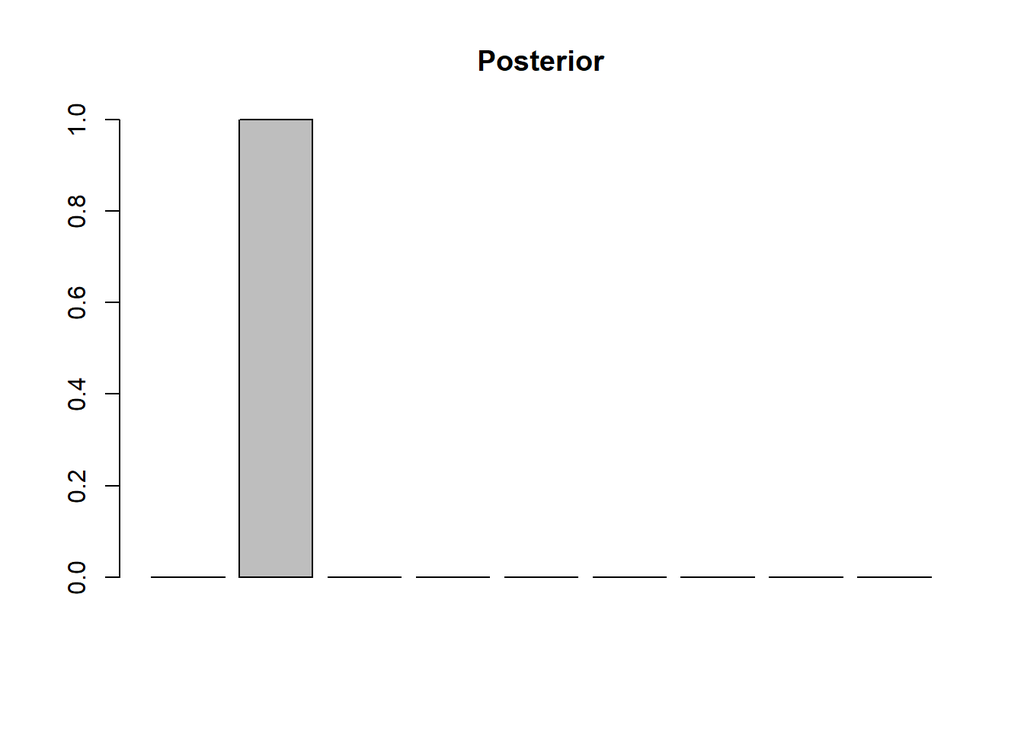

```r
barplot(posterior3, main="Posterior")
```

## **3. Frequentist vs Bayesian Inference**

> The example of M&Ms:  
> We have a population of M&Ms and the % of yellow M&Ms is either 10% or 20% (assume basically 5 colors)  
> Question:  
> Find whether the true % of yellow M&Ms is 10%

### **3.1 Frequentist Inference:**

### **H<sub>0</sub>: 10% yellow M&Ms.**

### **H<sub>A</sub>: >10% yellow M&Ms.**

### **alpha=0.05**

### Then with sample RBG**Y**O, got obs data: k=1, n=5

$$P(K>=1 | n=5, p=0.1) = 1-P(k=0 | n=5, p=0.1) = 1 - 0.9^5 = ~0.41$$

### So p>0.05, accept H<sub>0</sub>, which means no significant evidences reject % of yellow = 10%.

### **3.2 Bayesian Inference:**

### **H<sub>1</sub>: 10% yellow M&Ms**

### **H<sub>2</sub>: 20% yellow M&Ms *(can test both %s instead of null vs alternative)***

### **prior: P(H<sub>1</sub>) = 0.5 = P(H<sub>2</sub>) *(since no believe that one prob is greater than the other)***

### Then with sample RBG**Y**O, got obs data: k=1, n=5

### Likelyhood:

$$P(k=1 | H_1) = \binom{5}{1} \, 0.1^1 \, (1-0.1)^{5-1} = 0.33$$
$$P(k=1 | H_2) = \binom{5}{1} \, 0.2^1 \, (1-0.2)^{5-1} = ~0.41$$

### Posterior

$$P(H_1 | k=1) = \frac{P(H_1)*P(k=1|H_1)}{P(k=1)} =
\frac{0.5*0.33}{0.5*0.33+0.5*0.41} = ~0.45$$

### And since only 2 situation (10% vs 20%), so the P(H<sub>2</sub> | k=1) = 1 - 0.45 = 0.55

### Although 0.55 vs 0.45 is not a strong choice to pick, if we have to, we can choose H<sub>2</sub> as conclusion. *(Note that it’s different conclusion than Frequentist inference)*

### Then a comparison of Bayesian inference vs Frequentist’s, with different obs. data is as below:

```r
obs_data <- c("n=5,  k=1",
              "n=10, k=2",
              "n=15, k=3",
              "n=20, k=4"
              )
freq_p <- c(0.41, 0.26, 0.18, 0.13)
bay_p10 <- c(0.45, 0.39, 0.34, 0.29)
bay_p20 <- c(0.55, 0.61, 0.66, 0.71)

library(dplyr)
tb_comp <- as.data.frame(cbind(obs_data,freq_p,bay_p10,bay_p20))

names(tb_comp) <- c("Obs.Data", "Freq P(k or more | 10% yellow)", "Bayesian P(10% yellow | n,k)","Bayesian P(20% yellow | n,k)")

library(kableExtra)

kable(tb_comp, format="html", escape=FALSE) %>%
  kable_styling(font_size = 20, full_width = TRUE) %>%
  column_spec(column = 4, background = "yellow", bold=TRUE)
```

| Obs.Data | Freq P(k or more \| 10% yellow) | Bayesian P(10% yellow \| n,k) | Bayesian P(20% yellow \| n,k) |
| --- | --- | --- | --- |
| n=5, k=1 | 0.41 | 0.45 | 0.55 |
| n=10, k=2 | 0.26 | 0.39 | 0.61 |
| n=15, k=3 | 0.18 | 0.34 | 0.66 |
| n=20, k=4 | 0.13 | 0.29 | 0.71 |

### Frequentist inference is sensitive to the hypothesis, while Bayesian is not.

```r
# R code: Bayesian one-arm sample size by predictive probability (assurance)
p0 <- 0.56    # historical / null rate
p1 <- 0.66    # assumed true rate for power/assurance calc
a  <- 1       # Beta(a,b) prior
b  <- 1
gamma <- 0.95 # posterior threshold P(p>p0) > gamma for "success"
psi   <- 0.80 # desired predictive probability (assurance)
maxn  <- 300  # search upper limit for n

posterior_prob_gt_p0 <- function(x, n, a, b, p0) {
  # 1 - CDF_Beta(p0; a+x, b+n-x)
  1 - pbeta(p0, a + x, b + n - x)
}

success_prob <- function(n, p1, a, b, p0, gamma) {
  xs <- 0:n
  probs <- dbinom(xs, size = n, prob = p1)
  post_probs <- sapply(xs, posterior_prob_gt_p0, n = n, a = a, b = b, p0 = p0)
  sum(probs[ post_probs > gamma ])
}

# search minimal n
found <- FALSE
for (n in 1:maxn) {
  sp <- success_prob(n, p1, a, b, p0, gamma)
  if (sp >= psi) {
    cat("Minimal n =", n, ", predictive success probability =", round(sp,4), "\n")
    found <- TRUE
    break
  }
}
```

```
## Minimal n = 143 , predictive success probability = 0.8062
```

```r
if (!found) cat("No n <= ", maxn, " achieves the target. Increase maxn or change parameters.\n")
```